# FML3

Vaishnavi

2023-10-23

```r
library(class)
library(caret)
library(e1071)
```

#Read the data.

```r
universal.df <- read.csv("UniversalBank.csv")
dim(universal.df)
```

```
## [1] 5000   14
```

```r
head(universal.df)
```

```
##   ID Age Experience Income ZIP.Code Family CCAvg Education Mortgage
## 1  1  25          1     49    91107      4   1.6         1        0
## 2  2  45         19     34    90089      3   1.5         1        0
## 3  3  39         15     11    94720      1   1.0         1        0
## 4  4  35          9    100    94112      1   2.7         2        0
## 5  5  35          8     45    91330      4   1.0         2        0
## 6  6  37         13     29    92121      4   0.4         2      155
##   Personal.Loan Securities.Account CD.Account Online CreditCard
## 1             0                  1          0      0          0
## 2             0                  1          0      0          0
## 3             0                  0          0      0          0
## 4             0                  0          0      0          0
## 5             0                  0          0      0          1
## 6             0                  0          0      1          0
```

```r
tail(universal.df)
```

```
##        ID Age Experience Income ZIP.Code Family CCAvg Education Mortgage
## 4995 4995  64         40     75    94588      3   2.0         3        0
## 4996 4996  29          3     40    92697      1   1.9         3        0
## 4997 4997  30          4     15    92037      4   0.4         1       85
## 4998 4998  63         39     24    93023      2   0.3         3        0
## 4999 4999  65         40     49    90034      3   0.5         2        0
## 5000 5000  28          4     83    92612      3   0.8         1        0
##      Personal.Loan Securities.Account CD.Account Online CreditCard
## 4995             0                  0          0      1          0
## 4996             0                  0          0      1          0
## 4997             0                  0          0      1          0
## 4998             0                  0          0      0          0
## 4999             0                  0          0      1          0
## 5000             0                  0          0      1          1
```

```r
#transposing dataframe
t(t(names(universal.df)))
```

```
##       [,1]
##  [1,] "ID"
##  [2,] "Age"
##  [3,] "Experience"
##  [4,] "Income"
##  [5,] "ZIP.Code"
##  [6,] "Family"
##  [7,] "CCAvg"
##  [8,] "Education"
##  [9,] "Mortgage"
## [10,] "Personal.Loan"
## [11,] "Securities.Account"
## [12,] "CD.Account"
## [13,] "Online"
## [14,] "CreditCard"
```

```r
New_Universal.df <- universal.df[,-c(1,5)]
dim(New_Universal.df)
```

```
## [1] 5000   12
```

Conversion of integer attributes to character for education variable

```r
New_Universal.df$Education <- as.factor(New_Universal.df$Education)
```

Dummy variables for Education

```r
dum <- dummyVars(~.,data = New_Universal.df)
the_data <- as.data.frame(predict(dum,New_Universal.df))
```

Division of dataset into (60%)of training and (40%) of validation set

```r
set.seed(1)
train.df <- sample(row.names(the_data), 0.6*dim(the_data)[1])
valid.df <- setdiff(row.names(the_data),train.df)
train <- the_data[train.df,]
valid <- the_data[valid.df,]
t(t(names(train)))
```

```
##       [,1]
##  [1,] "Age"
##  [2,] "Experience"
##  [3,] "Income"
##  [4,] "Family"
##  [5,] "CCAvg"
##  [6,] "Education.1"
##  [7,] "Education.2"
##  [8,] "Education.3"
##  [9,] "Mortgage"
## [10,] "Personal.Loan"
## [11,] "Securities.Account"
## [12,] "CD.Account"
## [13,] "Online"
## [14,] "CreditCard"
```

```r
summary(train)
```

```
##       Age          Experience        Income           Family
##  Min.   :23.00   Min.   :-3.00   Min.   :  8.00   Min.   :1.000
##  1st Qu.:36.00   1st Qu.:10.00   1st Qu.: 39.00   1st Qu.:1.000
##  Median :45.00   Median :20.00   Median : 63.00   Median :2.000
##  Mean   :45.43   Mean   :20.19   Mean   : 73.08   Mean   :2.388
##  3rd Qu.:55.00   3rd Qu.:30.00   3rd Qu.: 98.00   3rd Qu.:3.000
##  Max.   :67.00   Max.   :43.00   Max.   :224.00   Max.   :4.000
##      CCAvg         Education.1      Education.2     Education.3
##  Min.   : 0.000   Min.   :0.0000   Min.   :0.000   Min.   :0.0000
##  1st Qu.: 0.700   1st Qu.:0.0000   1st Qu.:0.000   1st Qu.:0.0000
##  Median : 1.500   Median :0.0000   Median :0.000   Median :0.0000
##  Mean   : 1.915   Mean   :0.4173   Mean   :0.285   Mean   :0.2977
##  3rd Qu.: 2.500   3rd Qu.:1.0000   3rd Qu.:1.000   3rd Qu.:1.0000
##  Max.   :10.000   Max.   :1.0000   Max.   :1.000   Max.   :1.0000
##     Mortgage      Personal.Loan     Securities.Account   CD.Account
##  Min.   :  0.00   Min.   :0.00000   Min.   :0.0000     Min.   :0.00000
##  1st Qu.:  0.00   1st Qu.:0.00000   1st Qu.:0.0000     1st Qu.:0.00000
##  Median :  0.00   Median :0.00000   Median :0.0000     Median :0.00000
##  Mean   : 57.34   Mean   :0.09167   Mean   :0.1003     Mean   :0.05367
##  3rd Qu.:102.00   3rd Qu.:0.00000   3rd Qu.:0.0000     3rd Qu.:0.00000
##  Max.   :635.00   Max.   :1.00000   Max.   :1.0000     Max.   :1.00000
##      Online         CreditCard
##  Min.   :0.0000   Min.   :0.0000
##  1st Qu.:0.0000   1st Qu.:0.0000
##  Median :1.0000   Median :0.0000
##  Mean   :0.5847   Mean   :0.2927
##  3rd Qu.:1.0000   3rd Qu.:1.0000
##  Max.   :1.0000   Max.   :1.0000
```

```r
cat("size of training set is:",nrow(train))
```

```
## size of training set is: 3000
```

```r
summary(valid)
```

```
##       Age         Experience        Income           Family
##  Min.   :23.0   Min.   :-3.00   Min.   :  8.00   Min.   :1.000
##  1st Qu.:35.0   1st Qu.:10.00   1st Qu.: 39.00   1st Qu.:1.000
##  Median :45.0   Median :20.00   Median : 64.00   Median :2.000
##  Mean   :45.2   Mean   :19.97   Mean   : 74.81   Mean   :2.409
##  3rd Qu.:55.0   3rd Qu.:30.00   3rd Qu.: 99.00   3rd Qu.:3.000
##  Max.   :67.0   Max.   :43.00   Max.   :218.00   Max.   :4.000
##      CCAvg         Education.1     Education.2     Education.3
##  Min.   : 0.000   Min.   :0.000   Min.   :0.000   Min.   :0.000
##  1st Qu.: 0.700   1st Qu.:0.000   1st Qu.:0.000   1st Qu.:0.000
##  Median : 1.600   Median :0.000   Median :0.000   Median :0.000
##  Mean   : 1.973   Mean   :0.422   Mean   :0.274   Mean   :0.304
##  3rd Qu.: 2.600   3rd Qu.:1.000   3rd Qu.:1.000   3rd Qu.:1.000
##  Max.   :10.000   Max.   :1.000   Max.   :1.000   Max.   :1.000
##     Mortgage      Personal.Loan    Securities.Account   CD.Account
##  Min.   :  0.00   Min.   :0.0000   Min.   :0.0000     Min.   :0.0000
##  1st Qu.:  0.00   1st Qu.:0.0000   1st Qu.:0.0000     1st Qu.:0.0000
##  Median :  0.00   Median :0.0000   Median :0.0000     Median :0.0000
##  Mean   : 55.24   Mean   :0.1025   Mean   :0.1105     Mean   :0.0705
##  3rd Qu.: 97.25   3rd Qu.:0.0000   3rd Qu.:0.0000     3rd Qu.:0.0000
##  Max.   :617.00   Max.   :1.0000   Max.   :1.0000     Max.   :1.0000
##      Online        CreditCard
##  Min.   :0.000   Min.   :0.000
##  1st Qu.:0.000   1st Qu.:0.000
##  Median :1.000   Median :0.000
##  Mean   :0.615   Mean   :0.296
##  3rd Qu.:1.000   3rd Qu.:1.000
##  Max.   :1.000   Max.   :1.000
```

```r
cat("size of validation data set is:",nrow(valid))
```

```
## size of validation data set is: 2000
```

#normalization of dataset

```r
train.norm.df <- train[,-10]
valid.norm.df <- valid[,-10]
norm <- preProcess(train[,-10],method = c("center","scale"))
train.norm.df <- predict(norm,train[,-10])
valid.norm.df <- predict(norm,valid[,-10])
```

QUESTIONS 1

#Age = 40, Experience = 10, Income = 84, Family = 2, CCAvg = 2, Education_1 = 0, Education_2 =1, Education_3 = 0, Mortgage = 0, Securities Account = 0, CD Account = 0, Online = 1, and Credit Card = 1. Perform a k-NN classification with all predictors except ID and ZIP code using k = 1. Remember to transform categorical predictors with more than two categories into dummy variables first. Specify the success class as 1 (loan acceptance), and use the default cutoff value of 0.5. How would this customer be classified?

Creating data for given customer

```r
Given_cust <- data.frame(Age=40,Experience = 10,
                        Income = 84,
                        Family = 2,
                        CCAvg = 2,
                        Education.1 = 0,
                        Education.2 =1,
                        Education.3 = 0,
                        Mortgage = 0,
                        Securities.Account = 0,
                        CD.Account = 0,
                        Online = 1,
                        CreditCard = 1)
```

#Normalizing data for given customer

```r
Given_cust.norm <- predict(norm, Given_cust)
```

KNN classification

```r
Prediction <- class::knn(train = train.norm.df,
                         test = Given_cust.norm,
                         cl=train$Personal.Loan, k=1)
Prediction
```

```
## [1] 0
## Levels: 0 1
```

QUESTION 2

#What is a choice of k that balances between overfitting and ignoring the predictor information?

Claculation accuracy for K while setting range of k values to consider

```r
accuracy <- data.frame(k = seq(1, 15, 1), overallaccuracy = rep(0, 15))
for(i in 1:15) {
kn <- class::knn(train = train.norm.df,
test = valid.norm.df,
cl = train$Personal.Loan, k = i)
accuracy[i, 2] <- confusionMatrix(kn,
as.factor(valid$Personal.Loan),positive = "1")$overall[1]
}
which(accuracy[,2] == max(accuracy[,2]))
```

```
## [1] 3
```

```r
accuracy
```

```
##     k overallaccuracy
## 1   1          0.9630
## 2   2          0.9565
## 3   3          0.9640
## 4   4          0.9595
## 5   5          0.9605
## 6   6          0.9575
## 7   7          0.9580
## 8   8          0.9575
## 9   9          0.9535
## 10 10          0.9550
## 11 11          0.9495
## 12 12          0.9475
## 13 13          0.9500
## 14 14          0.9500
## 15 15          0.9485
```

When k=3, the problem of balancing between overfitting and ignoring the predictor information is solved

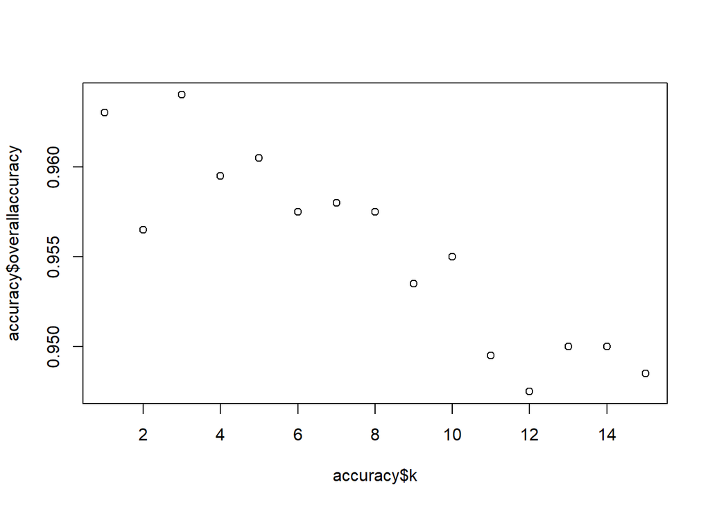

```r
plot(accuracy$k,accuracy$overallaccuracy)
```

UESTION 3

#Show the confusion matrix for the validation data that results from using the best k.

```r
Predic_df <- class::knn(train = train.norm.df,
                        test= valid.norm.df,
                        cl=train$Personal.Loan, k=3)
confusionMatrix(Predic_df,as.factor(valid$Personal.Loan))
```

```
## Confusion Matrix and Statistics
##
##           Reference
## Prediction    0    1
##          0 1786   63
##          1    9  142
##
##                Accuracy : 0.964
##                  95% CI : (0.9549, 0.9717)
##     No Information Rate : 0.8975
##     P-Value [Acc > NIR] : < 2.2e-16
##
##                   Kappa : 0.7785
##
##  Mcnemar's Test P-Value : 4.208e-10
##
##             Sensitivity : 0.9950
##             Specificity : 0.6927
##          Pos Pred Value : 0.9659
##          Neg Pred Value : 0.9404
##              Prevalence : 0.8975
##          Detection Rate : 0.8930
##    Detection Prevalence : 0.9245
##       Balanced Accuracy : 0.8438
##
##        'Positive' Class : 0
##
```

QUESTION 4

Data for given customer 2

```r
Given_2cust.df <- data.frame(Age = 40,
                             Experience = 10,
                             Income = 84,
                             Family = 2,
                             CCAvg = 2,
                             Education.1 = 0,
                             Education.2 = 1,
                             Education.3 = 0,
                             Mortgage = 0,
                             Securities.Account = 0,
                             CD.Account = 0,
                             Online = 1,
                             CreditCard = 1)
```

#normalizing data for given customer 2

```r
Given_2cust.df_norm <- predict(norm, Given_2cust.df)
```

QUESTIONS 5

```r
#Creation of Training index
set.seed(500)
Train_Index <- sample(row.names(the_data), .5*dim(the_data)[1])
```

#Creation of Validation index

```r
Valid_Index <- sample(setdiff(row.names(the_data),Train_Index), .3*dim(the_data)[1])
```

#Creation of Testing Index

```r
Test_Index <- setdiff(row.names(the_data),union(Train_Index,Valid_Index))
train.df <- the_data[Train_Index,]
cat("Size of new training set is:", nrow(train.df))
```

```
## Size of new training set is: 2500
```

```r
valid.df <- the_data[Valid_Index, ]
cat("Size of new Validation set is:", nrow(valid.df))
```

```
## Size of new Validation set is: 1500
```

```r
test.df <- the_data[Test_Index, ]
cat("Size of new Testing set is:", nrow(test.df))
```

```
## Size of new Testing set is: 1000
```

Normalization of data

```r
Norm_values <- preProcess(train.df[, -10], method=c("center", "scale"))
train.df.norm <- predict(Norm_values, train.df[, -10])
valid.df.norm <- predict(Norm_values, valid.df[, -10])
test.df.norm <- predict(Norm_values, test.df[,-10])
```

KNN Classification and Creation of Confusion Matrix

```r
Predic_3 <- class::knn(train.df.norm,
                       test.df.norm,
                       cl=train.df$Personal.Loan, k=3)

confusionMatrix(Predic_3,as.factor(test.df$Personal.Loan))
```

```
## Confusion Matrix and Statistics
##
##           Reference
## Prediction   0   1
##          0 898  36
##          1   6  60
##
##                Accuracy : 0.958
##                  95% CI : (0.9436, 0.9696)
##     No Information Rate : 0.904
##     P-Value [Acc > NIR] : 9.200e-11
##
##                   Kappa : 0.7187
##
##  Mcnemar's Test P-Value : 7.648e-06
##
##             Sensitivity : 0.9934
##             Specificity : 0.6250
##          Pos Pred Value : 0.9615
##          Neg Pred Value : 0.9091
##              Prevalence : 0.9040
##          Detection Rate : 0.8980
##    Detection Prevalence : 0.9340
##       Balanced Accuracy : 0.8092
##
##        'Positive' Class : 0
##
```

```r
Predic_4 <-class::knn(train = train.df.norm,
                      test = valid.df.norm,
                      cl=train.df$Personal.Loan, k=3)
confusionMatrix(Predic_4, as.factor(valid.df$Personal.Loan))
```

```
## Confusion Matrix and Statistics
##
##           Reference
## Prediction    0    1
##          0 1332   66
##          1    8   94
##
##                Accuracy : 0.9507
##                  95% CI : (0.9385, 0.9611)
##     No Information Rate : 0.8933
##     P-Value [Acc > NIR] : 1.512e-15
##
##                   Kappa : 0.692
##
##  Mcnemar's Test P-Value : 3.446e-11
##
##             Sensitivity : 0.9940
##             Specificity : 0.5875
##          Pos Pred Value : 0.9528
##          Neg Pred Value : 0.9216
##              Prevalence : 0.8933
##          Detection Rate : 0.8880
##    Detection Prevalence : 0.9320
##       Balanced Accuracy : 0.7908
##
##        'Positive' Class : 0
##
```

#Overfitting: Overfitting may have happened if the training set outperforms the validation and test sets by a significant margin. It’s possible that the model trained too tightly to fit the training set, which prevented it from generalizing well.

#Data Quality: Differences in data quality, distribution, or the presence of outliers between the sets may have an effect on performance variances.

#Sample Size: If the validation and test sets have smaller sample sizes, performance measurements could be more erratic.

#Unpredictability: Variations may also arise from the randomness of the samples chosen for each set and the way the data is segmented.

#Hyperparameter tuning: A model’s performance may be affected by the selection of k in k-NN or other model-specific parameters, for example might have an impact on the performance of a model.